# Assignment 4: Decision Trees

Author

Solution by Dr. Theobold

````markdown
```{r}
#| label: setup
#| message: false
#| warning: false

library(tidyverse)
library(tidymodels)
library(rpart.plot)
library(discrim)
library(baguette)
library(janitor)

set.seed(87935)
```
````

# Dataset 1: Mushrooms

The first dataset we will study today concerns mushrooms that grow in the wild. An expert mushroom forager can identify the species by its appearance, and determine if the mushroom is edible or poisonous.

Can we train a model to do the same?

Read the data in as follows. (You do need the extra bit of code in the `read_csv` function, make sure you copy it over.)

````markdown
```{r}
mushrooms <- read_csv("https://www.dropbox.com/s/jk5q3dq1u63ey1e/mushrooms.csv?dl=1",
                      col_types = str_c(rep("c", 23), collapse = "")
                      )
```
````

You can find further documentation of the dataset here: https://www.kaggle.com/uciml/mushroom-classification

````markdown
```{r}
#| label: data-cleaning

mushrooms <- mushrooms %>%
  # Convert all variables to factors (since they are all characters)
  mutate(
    across(.cols = everything(),
           .fns = ~ as.factor(.x)
           )
    ) %>%
  # Clean the names of the columns
  janitor::clean_names()

mushrooms <- mushrooms %>%
  dplyr::select(-veil_type)
```
````

## Part One: A perfect tree

1. Fit a single decision tree to the **full** mushroom data, and plot the resulting tree. You should find that almost all mushrooms are perfectly classified; that is, the resulting leaf nodes are very close to 100% pure.

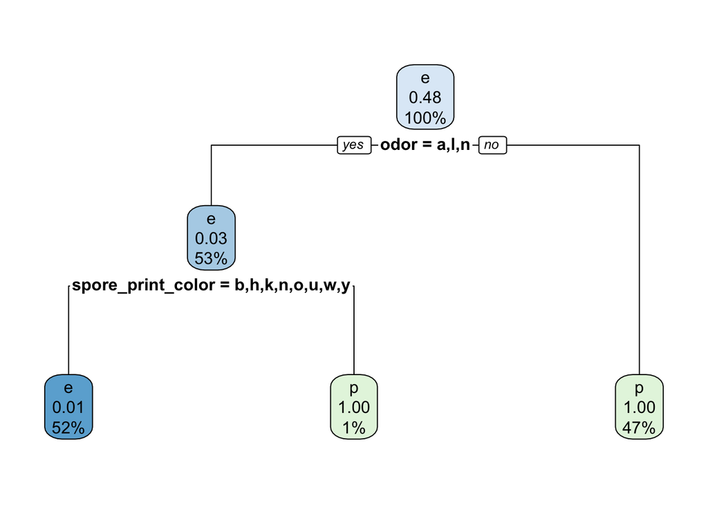

````markdown
```{r}
tree_spec <- decision_tree() %>%
  set_engine("rpart") %>%
  set_mode("classification")

mush_fit <- tree_spec %>%
  fit(class ~ ., data = mushrooms)

mush_fit$fit %>%
  rpart.plot(roundint = FALSE)
```
````

2. Based on the tree that results, suggest a “nature guide” that tells people which mushrooms are safe to eat and which aren’t.

First, check if your mushroom smells like creosote or smells fishy, foul, musty, pungent, or spicy. If any of these scents are present, don’t eat it, it’s poisonous!

## Part Two: … or is it?

Before we send people off into the world to each poisonous mushrooms, we want to be confident of our guidelines. The decision tree in Q1 may achieve perfection on the data it is fit to, but do we believe these guidelines will hold for future data?

Apply each of the following resampling and / or ensemble techniques to this classification problem. For each, you should either argue that

1. The classification rules we learned in Part One probably apply to all mushrooms; or
2. The classification rules we learned in Part One are overfit to this particular sample of mushrooms and / or set of predictors.
3. Cross-validation

````markdown
```{r}
#| label: mushroom-cv

mush_recipe <- recipe(class ~ ., mushrooms)

mush_wflow <- workflow() %>%
  add_model(tree_spec) %>%
  add_recipe(mush_recipe)

mush_cv <- vfold_cv(mushrooms, 5)

mush_wflow %>%
  fit_resamples(mush_cv) %>%
  collect_metrics()
```
````

```
# A tibble: 2 × 6
  .metric  .estimator  mean     n  std_err .config
  <chr>    <chr>      <dbl> <int>    <dbl> <chr>
1 accuracy binary     0.994     5 0.000603 Preprocessor1_Model1
2 roc_auc  binary     0.994     5 0.000673 Preprocessor1_Model1
```

We’re still getting over 99% accuracy even when we cross-validate. This assures us that we haven’t overfit our decision tree to this particular dataset.

4. Bagging

````markdown
```{r}
#| label: mushroom-bagging

bag_spec <- bag_tree() %>%
  set_engine("rpart", times = 10) %>%
  set_mode("classification")

mush_bag_wflow <- workflow() %>%
  add_model(bag_spec) %>%
  add_recipe(mush_recipe)

mush_bag_fit <- mush_bag_wflow %>%
  fit(mushrooms)

mushrooms %>%
  mutate(
    preds = predict(mush_bag_fit, mushrooms)$.pred_class
  ) %>%
  metrics(truth = class,
          estimate = preds)
```
````

```
# A tibble: 2 × 3
  .metric  .estimator .estimate
  <chr>    <chr>          <dbl>
1 accuracy binary             1
2 kap      binary             1
```

We’re now getting perfect accuracy from the bagged trees. This is perhaps not surprising; if we have enough information to near-perfectly sort the full dataset, we can almost certainly also sort any subsample nicely.

5. Random forests

````markdown
```{r}
#| label: mushroom-rf

# There are 22 total variables, so let's try up to 10 allowed per tree.
mtry_grid <- grid_regular(mtry(c(1, 10)),
                          levels = 5)

rf_spec <- rand_forest(mtry = tune()) %>%
  set_engine("ranger") %>%
  set_mode("classification")

mush_rf_wflow <- workflow() %>%
  add_model(rf_spec) %>%
  add_recipe(mush_recipe)

mush_rf_fit <- mush_rf_wflow %>%
  tune_grid(
    grid = mtry_grid,
    resamples = mush_cv
    )

mush_rf_fit %>%
  collect_metrics()
```
````

```
# A tibble: 10 × 7
    mtry .metric  .estimator  mean     n     std_err .config
   <int> <chr>    <chr>      <dbl> <int>       <dbl> <chr>
 1     1 accuracy binary     0.991     5 0.000904    Preprocessor1_Model1
 2     1 roc_auc  binary     1.00      5 0.000000607 Preprocessor1_Model1
 3     3 accuracy binary     1         5 0           Preprocessor1_Model2
 4     3 roc_auc  binary     1         5 0           Preprocessor1_Model2
 5     5 accuracy binary     1         5 0           Preprocessor1_Model3
 6     5 roc_auc  binary     1         5 0           Preprocessor1_Model3
 7     7 accuracy binary     1         5 0           Preprocessor1_Model4
 8     7 roc_auc  binary     1         5 0           Preprocessor1_Model4
 9    10 accuracy binary     1         5 0           Preprocessor1_Model5
10    10 roc_auc  binary     1         5 0           Preprocessor1_Model5
```

We’re getting perfect accuracy from the random forest as long as we allow more than one variable per tree in the forest. This is by far our strongest argument for our mushroom-eating plan: we might be concerned that there are so many variables in the dataset, we had too many options to split the data. But it appears that our good predictive power did not depend on any one or two specific variables, since the random forest still works great.

# Dataset 2: Telecom Customers

Congratulations! You have been hired by the Data Science division of a major telecommunication company.

The Sales division of the company wants to understand how customer demographics - such as their age, income, marital status, employment status, etc - impact the customer’s behavior. They have identified four different types of customers, and labeled a dataset of existing customers with these categories.

````markdown
```{r, eval = FALSE}
tele <- read_csv("https://www.dropbox.com/s/9dymy30v394ud8h/Telecust1.csv?dl=1")
```
````

Further documentation of this data can be found here: https://www.kaggle.com/prathamtripathi/customersegmentation

You’ve been tasked with studying the customer demographics and customer categories. The company would like two results from you:

1. A model that can be used to predict what category a new customer who signs up will likely fall into.
2. Insight into what demographics are associated with these customer differences.

#### Part Four: Report to your manager

Your manager, the head of the Data Science department, would like a summary of your work. She does not need to see every single detail of every step of your process, but she does need to know a basic outline of what you tried, how you made your decisions, and why you settled on certain choices.

You can assume she has taken Stat 551, and you may use any “lingo” you want; for example, you can reference the Gini Index without having to explain what it is.

#### Part Five: Report to Sales

Now that your manager has approved your work, you’re ready to present the results to Sales. The Sales team has zero data science training. They have some understanding of things like percentages, means, and medians - but they do not know or care about modeling details.

Summarize the results of your work in a way that is understandable to the Sales team, and only contains the level of technical detail that they might need to properly use the results in their job. You should NOT use any lingo. For example, instead of saying “We chose the model with highest precision”, you should say, “We chose the model that was least likely to misclassify an A-type customer as B-type.”